# ANTsR fMRI Questions

Brian B. Avants et al.

November 24, 2014

# Basic Goals

- Perform first level statistics for task fMRI with ANTsR
- Map the activation images to the template, assuming `antsCorticalThickness` was run.
- Test on public data, simple task.
- see fMRIANTs for this source file.

# Preprocessing for fMRI to perform: Assume co-registration happens later

- Define study parameters
- Read the image
- Look at it: DVARs
- `antsPreprocessfMRI`: motion correction, nuisance estimation
- look again
- Define model
- Do 1st level stats

# Brain mask issues

- define from BOLD or from act?

# Preprocessing for fMRI to perform: $\beta$s and Co-registration

- Map to subject T1
- ToDo: Enable imputation etc for dealing with corrupted data

# Define study parameters

```r
library(ANTsR)
```

```r
library(RKRNS)
basedir<-"/Users/stnava/data/fMRIANTs/" # FIXME for your study
setwd(basedir)
motionAcc<-0 # motion accuracy - 0 is for testing, 1 or 2 real studies
gtemplate<-antsImageRead("data2/template2mil.nii.gz",3)
t1<-antsImageRead("data2/t1_2mil.nii.gz",3)
ipttrn<-glob2rx(paste("*boldTask.nii.gz",sep=''))
fns<- paste(basedir,list.files(path=basedir,
  pattern = ipttrn ,recursive=T),sep='/')
designfn<-paste(basedir,"data2/designmat.csv",sep='')
if ( all(dim(gtemplate)==1) | ! file.exists(designfn)
     | all(dim(t1)==1) |  !file.exists(fns[1]) )
  stop(paste("Check your working directory",basedir))
```

# Define output variables

Define output prefix for this subject - usually would contain *unique ID* concatenated with the *scan date*.

E.g. “110099_20150108”.

```r
prefix<-paste(basedir,"TEMP",sep='') # paste(tempfile())
figpre<-paste(basedir,"ANTsRfMRI_FAQ_files/figure-html/fig",sep='')
figpre<-paste(basedir,"TEMP_fig",sep='')
```

# Quick T1 to template map

```r
if ( ! exists("templateMaps") )
  {
  templateMaps<-antsRegistration(gtemplate,t1,
    typeofTransform = "SyN",outprefix = prefix)
  antsImageWrite(templateMaps$warpedmovout,
    paste(prefix,'t1warped.nii.gz',sep=''))
  }
```

```
## use simple parameterization
```

```
## [1] 0
```

# Deal with subject specific parameters (AFNI style)

- number of runs? organize denoising by run etc
- length of runs
- alternative: estimate polynomial degree of noise? (polort)
- timing files / study design, if it varies per subject
- e.g. look at only correct trials …

# Read the image

```r
fn<-fns[1]
if ( ! file.exists(fn) )
  {
  fn<-file.choose()
  }
bold<-antsImageRead(fn,4)
```

# Get time series average

```r
avg<-getAverageOfTimeSeries(bold)
```

# Show the image

```
## [1] 0
```

# Show the image

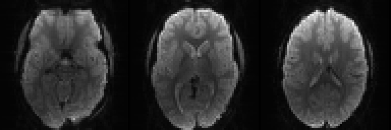

# Get Mask

```r
N3BiasFieldCorrection(3,avg,avg,2)
```

```
## [1] 0
```

```r
N3BiasFieldCorrection(3,avg,avg,2)
```

```
## [1] 0
```

```r
mask<-getMask(avg,mean(avg),Inf,2)
mat<-timeseries2matrix(bold, mask)
```

# Show the DVARs

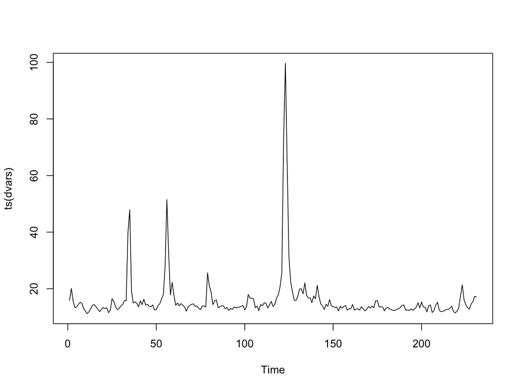

```r
dvars<-computeDVARS(mat)
plot(ts(dvars))
```

```r
# detect outliers?
```

# Show Time Slice Before Motion Correction

```r
  boldarr<-as.array(bold)
  bold2d<-as.antsImage(t(boldarr[20,20,,]))
  onm2da=paste(figpre,'slices2da.png',sep='')
  plotANTsImage(bold2d,outname=onm2da)
```

```
## [1] 0
```

# Show Time Slice Before Motion Correction

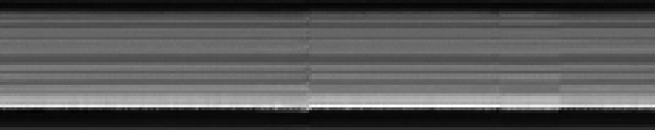

# Get TR and ntime volumes

```r
  tr<-antsGetSpacing(bold)[4]
  nbold<-dim(bold)[4]
```

# Read design file

Contains binary entries indicating event onsets w.r.t. volumes.

```r
  designmat<-read.csv(designfn)
```

# Show design

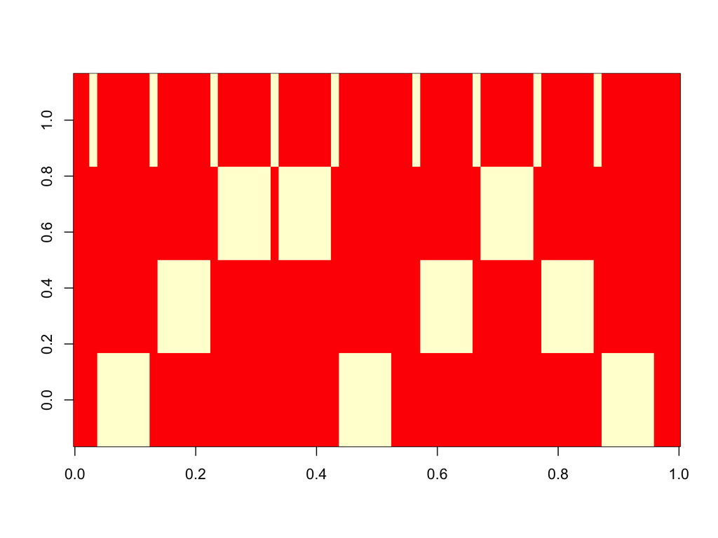

# Standard preprocessing for fMRI

What is being done here?

- COMPCOR
- Motion correction
- … other options

```r
  boldpre<-antsPreprocessfMRI( bold, mask, residualizeMatrix=T,
      spatialSmoothingType='gaussian', useMotionCorrectedImage=T,
      motionCorrectionAccuracyLevel = motionAcc,
      spatialSmoothingParameters=0, numberOfCompCorComponents=6 )
```

```
## Empty matrix created. ElementType: 'double'
##  [1] "MOCOparam0"  "MOCOparam1"  "MOCOparam2"  "MOCOparam3"  "MOCOparam4"
##  [6] "MOCOparam5"  "MOCOparam6"  "MOCOparam7"  "MOCOparam8"  "MOCOparam9"
## [11] "MOCOparam10" "MOCOparam11" "compcorr1"   "compcorr2"   "compcorr3"
## [16] "compcorr4"   "compcorr5"   "compcorr6"
```

# Show Time Slice After Motion $+$ Nuisance Residuals

```r
  boldarr<-as.array(boldpre$cleanBoldImage)
  bold2d<-as.antsImage(t(boldarr[20,20,,]))
  onm2db=paste(figpre,'slices2db.png',sep='')
  plotANTsImage(bold2d,outname=onm2db)
```

```
## [1] 0
```

# Show Time Slice After Motion $+$ Nuisance Residuals

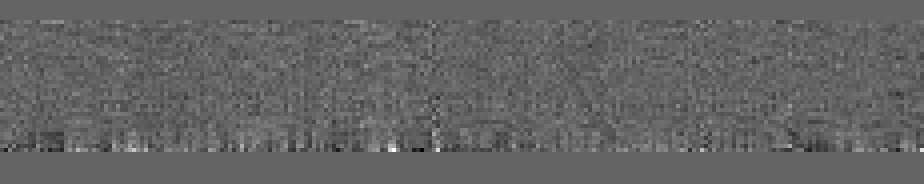

# Look at DVARS in corrected data

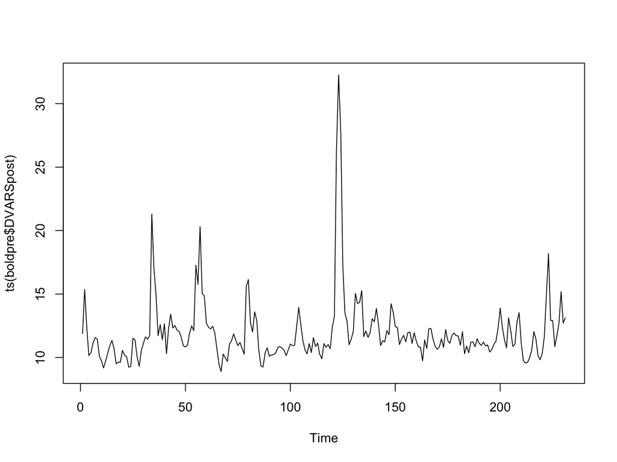

```r
plot(ts(boldpre$DVARSpost))
```

# Look at FD in corrected data

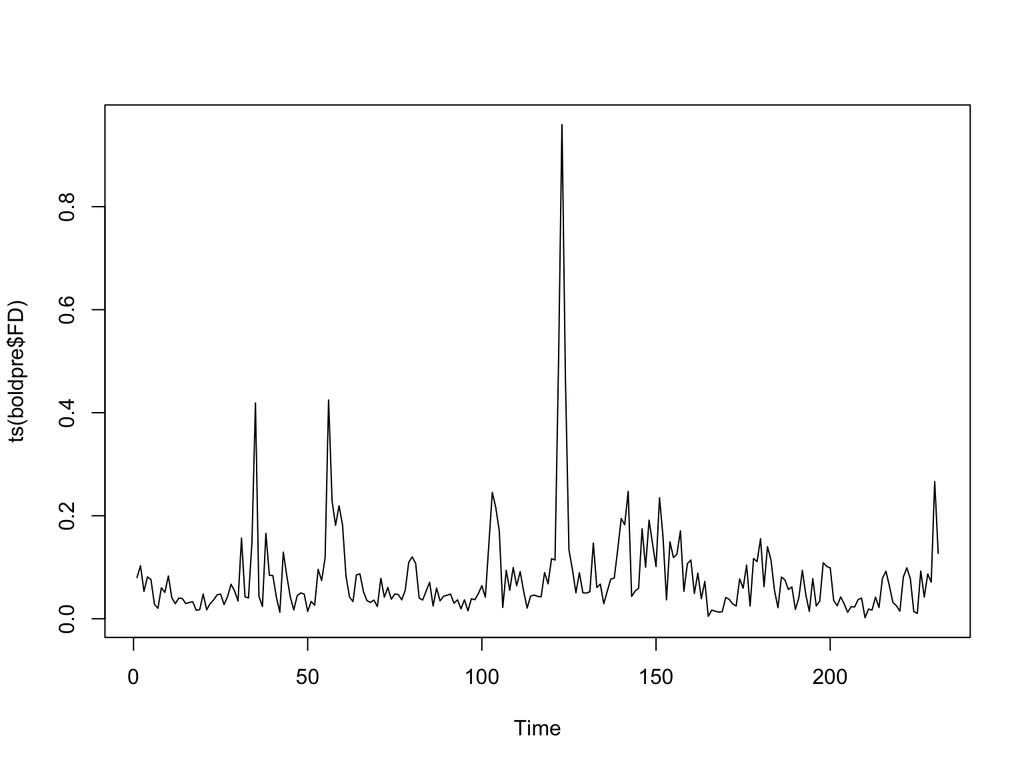

```r
plot(ts(boldpre$FD))
```

# Look at COMPCOR or other nuisance variables

Observe the compcor nuisance variables.

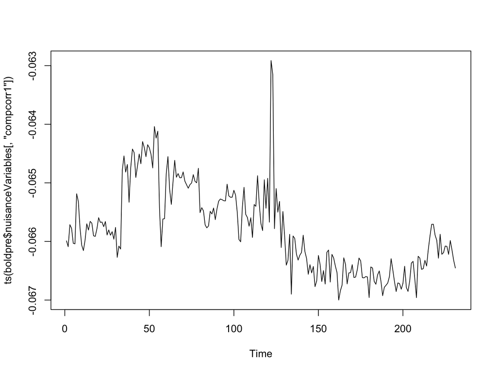

```r
plot(ts(boldpre$nuisanceVariables[,"compcorr1"]))
```

# Look at COMPCOR or other nuisance variables

Observe the compcor nuisance variables: 2.

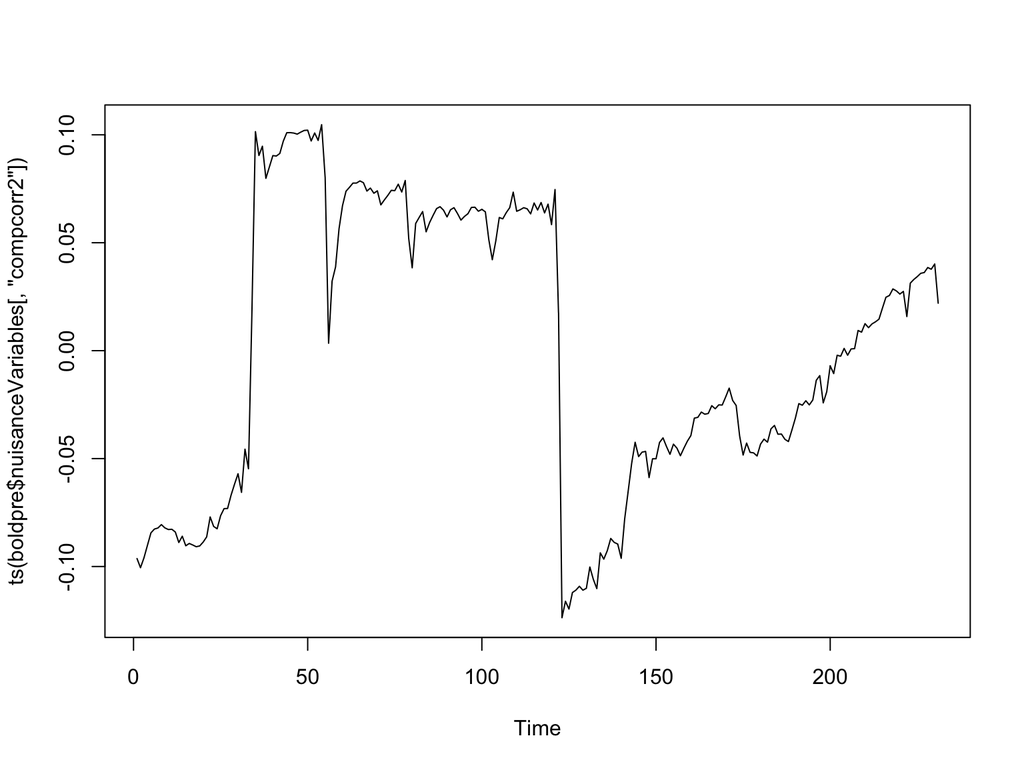

```r
plot(ts(boldpre$nuisanceVariables[,"compcorr2"]))
```

# Select your nuisance parameters

```r
  print(colnames(boldpre$nuisanceVariables))
```

```
##  [1] "MOCOparam0"  "MOCOparam1"  "MOCOparam2"  "MOCOparam3"  "MOCOparam4"
##  [6] "MOCOparam5"  "MOCOparam6"  "MOCOparam7"  "MOCOparam8"  "MOCOparam9"
## [11] "MOCOparam10" "MOCOparam11" "compcorr1"   "compcorr2"   "compcorr3"
## [16] "compcorr4"   "compcorr5"   "compcorr6"
```

```r
  nuis<-cbind(boldpre$nuisanceVariables,
    DVARS=boldpre$DVARS,FD=boldpre$FD)
```

# Smooth and rebuild cleaned BOLD image

```r
  bold<-antsImageClone( boldpre$cleanBoldImage )
  SmoothImage(4,bold,3.0,bold)
```

```
## [1] 0
```

```r
  mat<-timeseries2matrix( bold, mask  )
```

# Define subject-specific HRF

Make a block-like function for this design.

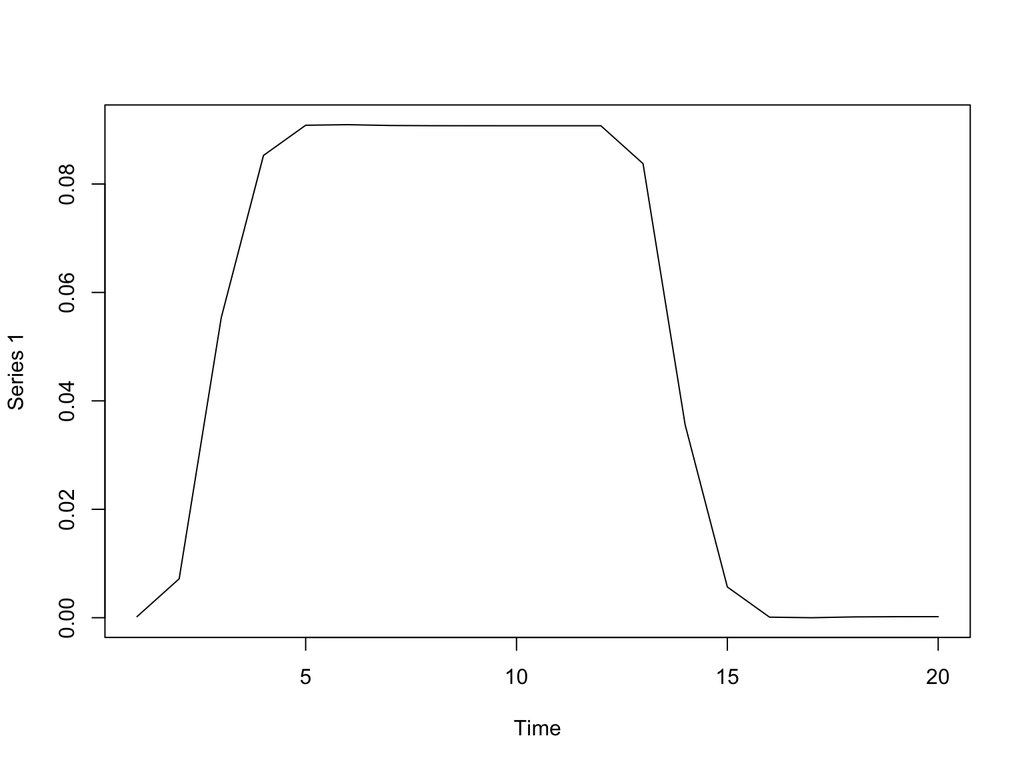

```r
hrf<-ts( hemodynamicRF(scans=20, onsets=0, durations=12, rt=tr,cc=0.5,a1=8,a2=9))
plot(hrf)
```

# Do convolution with design matrix

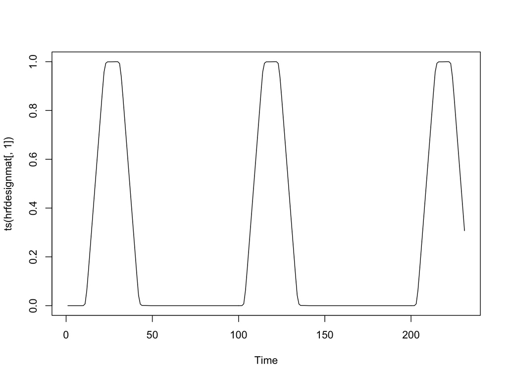

# Do first level statistics

```r
  mdl<-lm( mat ~ A+B+C+D+nuis , data=hrfdesignmat )
  execbetas<-bigLMStats( mdl, 0.0001 )
  print( rownames( execbetas$beta.t ) )
```

```
##  [1] "A"               "B"               "C"
##  [4] "D"               "nuisMOCOparam0"  "nuisMOCOparam1"
##  [7] "nuisMOCOparam2"  "nuisMOCOparam3"  "nuisMOCOparam4"
## [10] "nuisMOCOparam5"  "nuisMOCOparam6"  "nuisMOCOparam7"
## [13] "nuisMOCOparam8"  "nuisMOCOparam9"  "nuisMOCOparam10"
## [16] "nuisMOCOparam11" "nuiscompcorr1"   "nuiscompcorr2"
## [19] "nuiscompcorr3"   "nuiscompcorr4"   "nuiscompcorr5"
## [22] "nuiscompcorr6"   "nuisDVARS"       "nuisFD"
```

```r
# NOTE - coefficient differences
  betas<-makeImage( mask,
    execbetas$beta["C",]-execbetas$beta["A",] )
```

# Write some results

```r
  antsImageWrite(betas,paste(prefix,'tbetas.nii.gz',sep=''))
```

```
## [1] 0
```

```r
  antsImageWrite(avg,paste(prefix,'avg.nii.gz',sep=''))
```

```
## [1] 0
```

```r
  write.csv( nuis, paste(prefix,'nuis.csv',sep=''),row.names=F)
```

# Map to the T1 brain

The `t1brain` : 2mm version here, for speed.

```r
  if (!exists("t1brain")) t1brain<-antsImageClone(t1)
  if (!exists("mytx"))
    {
    mytx<-antsRegistration(fixed=avg, moving=t1brain,
      typeofTransform="SyNBold",
      outprefix=paste(prefix,"B",sep=''))
    }
```

```
## use simple parameterization
```

# Apply mapping to the template through the T1

- note order of transformations given above `antsRegistration` calls

```r
  wnm<-templateMaps$fwdtransforms[[1]]
  anm<-templateMaps$fwdtransforms[[2]]
    fulltx<-c(wnm,anm,mytx$invtransforms[1],
      mytx$invtransforms[2])
    wbeta<-antsApplyTransforms(fixed=gtemplate,
      moving=avg, transformlist=fulltx,
      whichtoinvert=c(F,F,T,F) )
    wbetafn<-paste(prefix,'avgw.nii.gz',sep='')
    antsImageWrite(wbeta,wbetafn)
```

```
## [1] 0
```

# Apply mapping to the template through the T1

- group template is 2mm version

```r
    wbeta<-antsApplyTransforms(fixed=gtemplate,
      moving=betas, transformlist=fulltx,
      whichtoinvert=c(F,F,T,F) )
    wbetafn<-paste(prefix,'tbetasw.nii.gz',sep='')
    antsImageWrite(wbeta,wbetafn)
```

```
## [1] 0
```

# Do group stats

See [ANTsR examples](http://stnava.github.io/ANTsR/)

```r
# see antsr documentation for how this might be done
# on the warped beta images
```

# Show on group template

```r
onm=paste(figpre,'betas.png',sep='')
th<-paste("3.0x",as.character(max(wbeta)),sep='')
plotANTsImage(gtemplate,functional=list(wbeta), thresh=th,
  color='jet',slices='48x62x4',axis=3,outname=onm)
```

# Show on group template

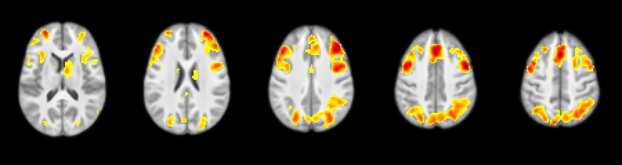

# $\beta$ histogram

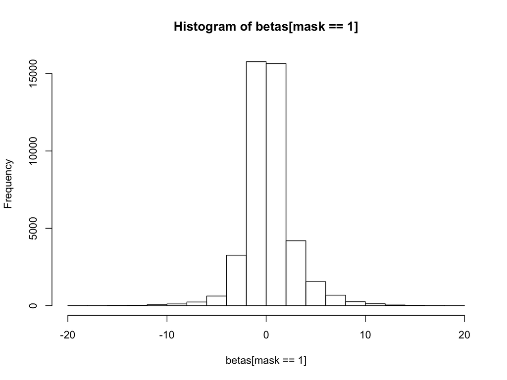

```r
hist( betas[ mask  == 1  ]   )
```